# Biomes

Organisms on Earth have adapted to the cyclic pattern of climate. Take as example deciduous plants; they thrive in spring to reproduce and loose their foliage in the fall to conserve energy in the harsh winter. Next year, they do the same. This is known as phenology, the cyclic and seasonal phenomena in nature. As a result, we find entire geographic regions inhabited by communities of organisms with similar adaptations. We call these regions biomes.  
The main objectives for today are to:

- Identify biomes given their climate diagrams
- Explore why biomes are being reconsidered in the anthropocene (anthropogenic biomes)

Resources:

- [Ellis EC, Ramankutty N. (2008). Putting people in the map: anthropogenic biomes of the world. Front. Ecol. Environ., 6:439–447](https://esajournals.onlinelibrary.wiley.com/doi/full/10.1890/070062)
- [HHMI BioInteractive, Grayson (2018) Mapping Coral Bleaching Modified with NOAA and Authentic Bleaching data. HHMI BioInteractive FMN (2016), QUBES Educational Resources. doi:10.25334/Q4NM3K](https://qubeshub.org/qubesresources/publications/319/1)

Datasets (to download, Save As Page Source):

- [puertorico](http://raisahernandez.github.io/General-Ecology/puertorico.csv)

**Part I: Terrestrial biomes and climate diagrams**

Step 1: Identify a terrestrial biome given its climate diagram

To visualize the patterns of temperature and precipitation that are associated with particular biomes, we can use climate diagrams. Since climate is the primary abiotic force shaping plant forms in different terrestrial biomes, you can expect locations around the world that are from a particular biome to have similar climate diagrams.

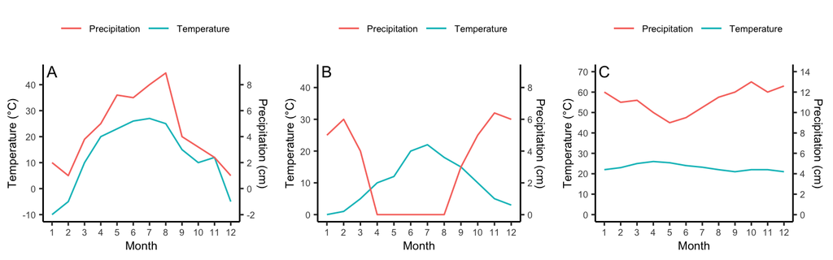

> **Question 1:** How many variables and what type of variables (e.g., categorical, continuous) each figure has?

> **Question 2:** If plant growth occurs when temperature > 0°C, how long is the plant growing season in biomes A, B and C?

> **Question 3:** According to these climate diagrams, plant growth is limited by what factor in each scenario?

> **Question 4:** These climate diagrams most likely belong to what type of biomes? Explain.

**Part II: Biomes and climate change**

Step 1: Explore the annual variation in temperature of coral reefs

In contrast to terrestrial biomes which are dominated by plants as primary producers, aquatic biomes are categorized by flow, depth and salinity. Take for instance coral reefs. Given the corals’ dependency on solar radiation for photosynthesis and their limited tolerance to seasonal changes in water temperature, this biome is constrained to shallow waters between 30°N and 30°S. However, several decades of climate change has put this biome - the second most diverse on Earth - under threat, opening questions into the boundaries of current biomes.

Go ahead, import “puertorico” to RStudio and explore the temperature data from coral reefs of Puerto Rico.

Plot the **average** temperature across months of one “normal” year (2004) and one “warm” year (2005). To get a summary of descriptive statistics (mean, SD, SE, 95%CI), use the function summarySE() in package Rmisc. The first argument in this function is the dataframe (puertorico), and the subsequent arguments are the column name of the variable to be summarized (dependent variable) and the column name containing the grouping variable (independent variable).

```r
# Loading package tidyverse to filter data
library(tidyverse)

# Filtering data from 2004 and 2005
pr04 <- filter(puertorico,BYYY==2004)
pr05 <- filter(puertorico,BYYY==2005)

# Check the newly created dataframes
pr04
pr05

# Loading package Rmisc to estimate average temperature (SST) across months (BM) in 2004 and 2005
library(Rmisc)
sum04 <- summarySE(pr04,"SST","BM")
sum05 <- summarySE(pr05,"SST","BM")

# Plotting the average temperature (SST) across months (BM) in 2004 and 2005
library(ggplot2)
p1 <- ggplot(sum04,aes(BM,SST)) +
  geom_line() +
  ylim(24,30) +
  theme_classic()+
  scale_x_continuous(breaks=seq(1,12,1)) +
  xlab("Month")
p1

p2 <- ggplot(sum05,aes(BM,SST)) +
  geom_line() +
  ylim(24,30) +
  theme_classic()+
  scale_x_continuous(breaks=seq(1,12,1)) +
  xlab("Month")
p2
```

[output not shown]

> **Question 1:** Can you observe any difference in mean monthly temperature between both years? Explain.

> **Question 2:** If the historical mean monthly maximum for this region is 28.5°C and the bleaching threshold is 29.5°C, how many weeks of thermal stress these corals experienced in 2005 versus 2004 (approximately)?

**Coral bleaching** is the loss of color a coral experiences after expelling their symbiotic algae. Coral bleaching occurs when corals experience stress due to higher than average temperatures. If coral bleaching takes place for prolong periods of time (weeks) corals are likely to die from starvation due to the absence of food from the algae’s photosynthesis.

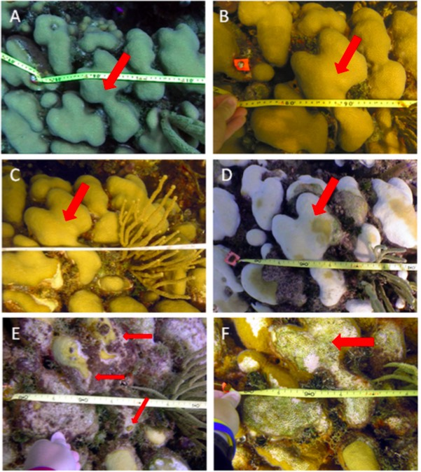

**Figure 1.** Temporal sequence of one photo-transect showing the same *Orbicella annularis* colonies in 2001, 2003-2007. The arrows points toward the same colony in different years. By 2007, the coral colony was dead. Hernández-Pacheco et al. 2011

> **Challenge:** Using today’s analysis and previous knowledge, make inferences about the potential consequences of climate change on current biome boundaries. What would you expect to happen if the rate of climate change is higher than the rate of evolution within populations?

**Part III: Anthropogenic biomes**

Erle Ellis and Navin Ramankutty (2008) proposed a reconsideration of biomes. In their model, they considered human population, land use (% pasture, crops, irrigation, rice, urban), and land cover (% vegetated). Their analysis identifies 6 major groups of biomes showed in the figure below.

Anthropogenic biomes (Ellis and Ramankutty 2008):

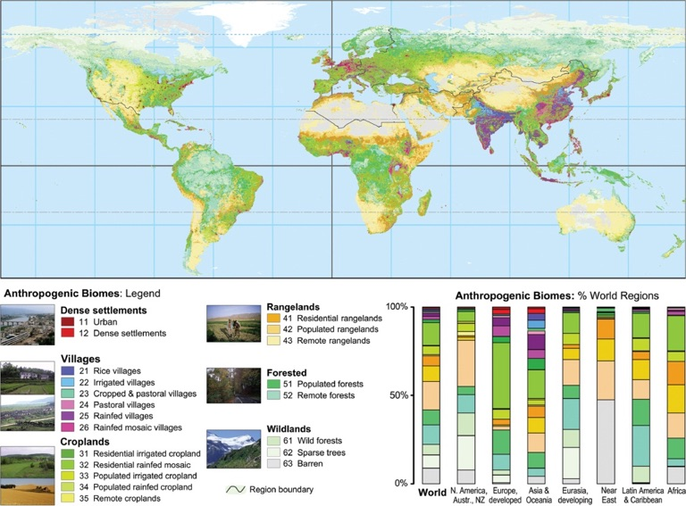

Terrestrial (historical) biomes:

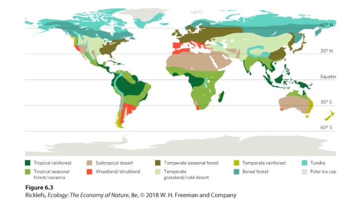

> **Challenge:** Compare Ellis and Ramankutty’s model with the terrestrial biome one. Is it meaningful to discuss about the primary productivity of a tropical seasonal forest biome when most of the native forest have been turned into fertilizer-supplemented and artificially irrigated croplands?

**FIN**

**Great Work!**